# **Milestone 1: EDA**

# **Make a project plan for your Reddit data with 10 topics that you plan on exploring.**

**Business Goal 1:** Improve content planning and resource allocation in the "dating_advice" subreddit by identifying the most active months, enabling the subreddit to provide more relevant and engaging content during peak periods.

- **Technical Proposal:** We will convert Unix timestamps to datetime objects, extract the year and month, and count subreddit occurrences for each month-year. By creating a bar plot, we will visualize the data to pinpoint the months with the highest subreddit activity. This analysis will reveal usage patterns and seasonality, providing insights for optimizing content strategies, posting schedules, and targeted promotions to increase user engagement and satisfaction.

**Business Goal 2:** Enhance content curation and user engagement by identifying the top 10 highly discussed Reddit post titles, including their scores and the number of comments, allowing the subreddit to feature the most popular and engaging content.

- **Technical Proposal:** We will extract post titles, scores, and comment counts from Reddit data. Leveraging data sorting and filtering techniques, we will identify the top 10 posts with the highest scores and comment counts. The results will be presented with the titles and their associated metrics, providing valuable insights for content selection and promotion, ultimately increasing user interaction and participation in the subreddit.

**Business Goal 3:** Improve post engagement and content strategy on Reddit by understanding the relationship between post scores and the number of comments.

- **Technical Proposal:** Conduct exploratory data analysis (EDA) to analyze the dataset, focusing on post scores and the number of comments. Create scatter plots to understand the correlation between comment scores and comment length, enabling Reddit moderators and content creators to optimize their strategies for higher engagement. Visualize the findings to aid in data-driven decision-making.

**Business Goal 4:** Enhance user insights and engagement by determining the dating apps most frequently discussed on Reddit's "dating_advice" subreddit.

- **Technical Proposal:** We will employ natural language processing (NLP) on Reddit posts and comments to identify mentions of dating apps. Text mining techniques will be used to pinpoint the dating app that is most frequently discussed on Reddit. The results will be presented with relevant metrics, including frequency and sentiment analysis.

**Business Goal 5:** Provide valuable insights into user sentiments over time by analyzing emotional changes across different months.

- **Technical Proposal:** Emotion scores for Reddit posts and comments will be calculated using the emotion recognition model. The data will be grouped by month, and we will analyze the fluctuations in emotion scores over time. Visualizations will be created to illustrate emotional trends across months.

**Business Goal 6:** Improve content understanding by generating word clouds that highlight the most common terms within the subreddit's content.

- **Technical Proposal:** Process the text data from Reddit posts and comments to create word clouds that visually represent the most frequently used words. The word clouds will provide an overview of the main topics and themes discussed in the subreddit.

**Business Goal 7:** Gain insights into the sentiment of Reddit posts by performing sentiment analysis on their textual content.

- **Technical Proposal:** Sentiment analysis tools will be utilized to assess the sentiment of the textual content in Reddit posts. The results will be presented with metrics, including the overall sentiment distribution and sentiment trends over time.

**Business Goal 8:** Determine the key factors that contribute to high post scores.

- **Technical Proposal:** A machine learning model will be developed to predict post scores based on features such as posting time, user age (over 18 or not), emotion scores, month, and sentiment. The model's performance will be evaluated, and the importance of each feature in determining post scores will be analyzed.

**Business Goal 9:** Build a model to predict whether a comment is likely to receive Reddit Gold (gilded).

- **Technical Proposal:** Machine learning models, including BERT, Random Forest, and Naive Bayes, will be employed to classify comments as likely to receive Reddit Gold or not. The model will be trained using historical gilding data and various text-based features.

**Business Goal 10:** Uncover meaningful topics from Reddit content by implementing topic modeling techniques.

- **Technical Proposal**: Topic modeling methods such as Latent Semantic Analysis (LSA), Latent Dirichlet Allocation (LDA), and Non-Negative Matrix Factorization (NMF) will be used to extract significant topics from Reddit posts and comments. These identified topics will be presented, and their prevalence and evolution over time will be analyzed.

# Launch spark environment

```python
spark
```

```
StatementMeta(78708167-420b-4a4f-8dc9-381051316aa9, 20, 6, Finished, Available)
```

**SparkSession - hive**

**SparkContext**

[Spark UI](http://vm-2c373136:42493)

**Version**

`v3.2.2.5.1-100879434`

**Master**

`yarn`

**AppName**

`Azure ML Experiment`

# Library

```python
from pyspark.sql.functions import *
import seaborn as sns
import pandas as pd
import matplotlib.pyplot as plt
from datetime import datetime
from pyspark.sql.functions import split, size
```

# **Report on the basic info about your dataset. What are the interesting columns? What is the schema? How many rows do you have? etc. etc.**

## Read subreddits (dating_advice) from submissions

```python
# The DataFrame has already filtered based on the 'subreddit' column
wasbs_base_url = "wasbs://azureml-blobstore-e15c4cc3-0839-4a1b-aaaa-31ad08c12628@group16astorage88769818a.blob.core.windows.net/"
submissions_path = "filtered-submissions-all"
submissions_df_dating = spark.read.parquet(f"{wasbs_base_url}{submissions_path}")
```

```
StatementMeta(78708167-420b-4a4f-8dc9-381051316aa9, 23, 8, Finished, Available)
```

```python
# show the shape
submissions_row_count = submissions_df_dating.count()
submissions_col_count = len(submissions_df_dating.columns)
print(f"shape of the submissions dataframe is {submissions_row_count:,}x{submissions_col_count}")
```

```
StatementMeta(78708167-420b-4a4f-8dc9-381051316aa9, 23, 9, Finished, Available)
```

```
shape of the submissions dataframe is 377,944x70
```

```python
submissions_df_dating.rdd.getNumPartitions()
```

```
StatementMeta(78708167-420b-4a4f-8dc9-381051316aa9, 23, 10, Finished, Available)
```

```
97
```

```python
# show the schema
submissions_df_dating.printSchema()
```

```
StatementMeta(78708167-420b-4a4f-8dc9-381051316aa9, 23, 11, Finished, Available)
```

```
root
 |-- adserver_click_url: string (nullable = true)
 |-- adserver_imp_pixel: string (nullable = true)
 |-- archived: boolean (nullable = true)
 |-- author: string (nullable = true)
 |-- author_cakeday: boolean (nullable = true)
 |-- author_flair_css_class: string (nullable = true)
 |-- author_flair_text: string (nullable = true)
 |-- author_id: string (nullable = true)
 |-- brand_safe: boolean (nullable = true)
 |-- contest_mode: boolean (nullable = true)
 |-- created_utc: timestamp (nullable = true)
 |-- crosspost_parent: string (nullable = true)
 |-- crosspost_parent_list: array (nullable = true)
 |    |-- element: struct (containsNull = true)
 |    |    |-- approved_at_utc: string (nullable = true)
 |    |    |-- approved_by: string (nullable = true)
 |    |    |-- archived: boolean (nullable = true)
 |    |    |-- author: string (nullable = true)
 |    |    |-- author_flair_css_class: string (nullable = true)
 |    |    |-- author_flair_text: string (nullable = true)
 |    |    |-- banned_at_utc: string (nullable = true)
 |    |    |-- banned_by: string (nullable = true)
 |    |    |-- brand_safe: boolean (nullable = true)
 |    |    |-- can_gild: boolean (nullable = true)
 |    |    |-- can_mod_post: boolean (nullable = true)
 |    |    |-- clicked: boolean (nullable = true)
 |    |    |-- contest_mode: boolean (nullable = true)
 |    |    |-- created: double (nullable = true)
 |    |    |-- created_utc: double (nullable = true)
 |    |    |-- distinguished: string (nullable = true)
 |    |    |-- domain: string (nullable = true)
 |    |    |-- downs: long (nullable = true)
 |    |    |-- edited: boolean (nullable = true)
 |    |    |-- gilded: long (nullable = true)
 |    |    |-- hidden: boolean (nullable = true)
 |    |    |-- hide_score: boolean (nullable = true)
 |    |    |-- id: string (nullable = true)
 |    |    |-- is_crosspostable: boolean (nullable = true)
 |    |    |-- is_reddit_media_domain: boolean (nullable = true)
```

[output cut: 197 more lines]

```
 |-- subreddit: string (nullable = true)
 |-- subreddit_id: string (nullable = true)
 |-- suggested_sort: string (nullable = true)
 |-- third_party_trackers: array (nullable = true)
 |    |-- element: string (containsNull = true)
 |-- third_party_tracking: string (nullable = true)
 |-- third_party_tracking_2: string (nullable = true)
 |-- thumbnail: string (nullable = true)
 |-- thumbnail_height: long (nullable = true)
 |-- thumbnail_width: long (nullable = true)
 |-- title: string (nullable = true)
 |-- url: string (nullable = true)
 |-- whitelist_status: string (nullable = true)
 |-- year: integer (nullable = true)
 |-- month: integer (nullable = true)
```

## Extract subreddits (dating_advice) from comments

```python
# The DataFrame has already filtered based on the 'subreddit' column
wasbs_base_url = "wasbs://azureml-blobstore-e15c4cc3-0839-4a1b-aaaa-31ad08c12628@group16astorage88769818a.blob.core.windows.net/"
comments_path = "filtered-comments-all3"
comments_df_dating = spark.read.parquet(f"{wasbs_base_url}{comments_path}")
```

```
StatementMeta(78708167-420b-4a4f-8dc9-381051316aa9, 23, 17, Finished, Available)
```

```python
# show the shape
comments_row_count = comments_df_dating.count()
comment_col_count = len(comments_df_dating.columns)
print(f"shape of the comments dataframe is {comments_row_count:,}x{comment_col_count}")
```

```
StatementMeta(78708167-420b-4a4f-8dc9-381051316aa9, 23, 7, Finished, Available)
```

```
shape of the comments dataframe is 4,646,814x23
```

```python
comments_df_dating.rdd.getNumPartitions()
```

```
StatementMeta(78708167-420b-4a4f-8dc9-381051316aa9, 23, 12, Finished, Available)
```

```
233
```

```python
# show the schema
comments_df_dating.printSchema()
```

```
StatementMeta(78708167-420b-4a4f-8dc9-381051316aa9, 23, 13, Finished, Available)
```

```
root
 |-- author: string (nullable = true)
 |-- author_cakeday: boolean (nullable = true)
 |-- author_flair_css_class: string (nullable = true)
 |-- author_flair_text: string (nullable = true)
 |-- body: string (nullable = true)
 |-- can_gild: boolean (nullable = true)
 |-- controversiality: long (nullable = true)
 |-- created_utc: timestamp (nullable = true)
 |-- distinguished: string (nullable = true)
 |-- edited: string (nullable = true)
 |-- gilded: long (nullable = true)
 |-- id: string (nullable = true)
 |-- is_submitter: boolean (nullable = true)
 |-- link_id: string (nullable = true)
 |-- parent_id: string (nullable = true)
 |-- permalink: string (nullable = true)
 |-- retrieved_on: timestamp (nullable = true)
 |-- score: long (nullable = true)
 |-- stickied: boolean (nullable = true)
 |-- subreddit: string (nullable = true)
 |-- subreddit_id: string (nullable = true)
 |-- year: integer (nullable = true)
 |-- month: integer (nullable = true)
```

# **Conduct basic data quality checks! Make sure there are no missing values, check the length of the comments, and remove rows of data that might be corrupted. Even if you think all your data is perfect, you still need to demonstrate that with your analysis.**

## Data cleaning

### Drop useless columns

```python
columns_to_select = ['id',
    'author','permalink','created_utc', 'num_comments',
    'score','subreddit', 'subreddit_id','title', 'selftext', 'over_18',
    'is_video', 'archived', 'gilded', 'stickied',
    'is_self','edited','locked','url'
]
# Select the specified columns
submissions_df_dating = submissions_df_dating.select(columns_to_select)
submissions_df_dating.printSchema()
```

```
StatementMeta(78708167-420b-4a4f-8dc9-381051316aa9, 23, 38, Finished, Available)
```

```
root
 |-- id: string (nullable = true)
 |-- author: string (nullable = true)
 |-- permalink: string (nullable = true)
 |-- created_utc: timestamp (nullable = true)
 |-- num_comments: long (nullable = true)
 |-- score: integer (nullable = true)
 |-- subreddit: string (nullable = true)
 |-- subreddit_id: string (nullable = true)
 |-- title: string (nullable = true)
 |-- selftext: string (nullable = true)
 |-- over_18: boolean (nullable = true)
 |-- is_video: boolean (nullable = true)
 |-- archived: boolean (nullable = true)
 |-- gilded: integer (nullable = true)
 |-- stickied: boolean (nullable = true)
 |-- is_self: boolean (nullable = true)
 |-- edited: string (nullable = true)
 |-- locked: boolean (nullable = true)
 |-- url: string (nullable = true)
```

```python
submissions_df_dating.show(5)
```

```
StatementMeta(78708167-420b-4a4f-8dc9-381051316aa9, 23, 39, Finished, Available)
```

```
+------+------------------+--------------------+-------------------+------------+-----+-------------+------------+--------------------+--------------------+-------+--------+--------+------+--------+-------+-------------+------+--------------------+
|    id|            author|           permalink|        created_utc|num_comments|score|    subreddit|subreddit_id|               title|            selftext|over_18|is_video|archived|gilded|stickied|is_self|       edited|locked|                 url|
+------+------------------+--------------------+-------------------+------------+-----+-------------+------------+--------------------+--------------------+-------+--------+--------+------+--------+-------+-------------+------+--------------------+
|qx4ol5|organic_neural_net|/r/dating_advice/...|2021-11-19 01:16:40|           8|    1|dating_advice|    t5_2s4kl|Am I crazy / is t...|I've been dating ...|  false|   false|   false|     0|   false|   true|1.637287898E9| false|https://www.reddi...|
|qx4opq|         [deleted]|/r/dating_advice/...|2021-11-19 01:16:52|           8|    6|dating_advice|    t5_2s4kl|      Guys and nudes|           [deleted]|  false|   false|   false|     0|   false|   true|        false| false|https://www.reddi...|
|qx4qm0|      unknown43789|/r/dating_advice/...|2021-11-19 01:19:49|           0|    1|dating_advice|    t5_2s4kl|Boyfriend has dep...|           [removed]|  false|   false|   false|     0|   false|   true|        false| false|https://www.reddi...|
|qx4qwa|        bubblylion|/r/dating_advice/...|2021-11-19 01:20:13|           8|    1|dating_advice|    t5_2s4kl|dating someone wi...|so I [20f] sort o...|  false|   false|   false|     0|   false|   true|        false| false|https://www.reddi...|
|qx4say|         [deleted]|/r/dating_advice/...|2021-11-19 01:22:25|           2|    1|dating_advice|    t5_2s4kl|About when you me...|           [deleted]|  false|   false|   false|     0|   false|   true|1.637285269E9| false|https://www.reddi...|
+------+------------------+--------------------+-------------------+------------+-----+-------------+------------+--------------------+--------------------+-------+--------+--------+------+--------+-------+-------------+------+--------------------+
only showing top 5 rows
```

```python
# List of columns to select
columns_to_select = ['id',
    'author', 'body', 'created_utc', 'score',
    'subreddit','subreddit_id', 'controversiality', 'gilded','can_gild',
    'permalink', 'stickied','year','month'
]
# Select the specified columns
comments_df_dating = comments_df_dating.select(columns_to_select)
comments_df_dating.printSchema()
```

```
StatementMeta(78708167-420b-4a4f-8dc9-381051316aa9, 23, 18, Finished, Available)
```

```
root
 |-- id: string (nullable = true)
 |-- author: string (nullable = true)
 |-- body: string (nullable = true)
 |-- created_utc: timestamp (nullable = true)
 |-- score: long (nullable = true)
 |-- subreddit: string (nullable = true)
 |-- subreddit_id: string (nullable = true)
 |-- controversiality: long (nullable = true)
 |-- gilded: long (nullable = true)
 |-- can_gild: boolean (nullable = true)
 |-- permalink: string (nullable = true)
 |-- stickied: boolean (nullable = true)
 |-- year: integer (nullable = true)
 |-- month: integer (nullable = true)
```

```python
comments_df_dating.show(5)
```

```
StatementMeta(78708167-420b-4a4f-8dc9-381051316aa9, 23, 19, Finished, Available)
```

```
+-------+-------------+--------------------+-------------------+-----+-------------+------------+----------------+------+--------+--------------------+--------+----+-----+
|     id|       author|                body|        created_utc|score|    subreddit|subreddit_id|controversiality|gilded|can_gild|           permalink|stickied|year|month|
+-------+-------------+--------------------+-------------------+-----+-------------+------------+----------------+------+--------+--------------------+--------+----+-----+
|hkrohig|    [deleted]|           [removed]|2021-11-15 21:10:50|    1|dating_advice|    t5_2s4kl|               0|     0|    true|/r/dating_advice/...|   false|2021|   11|
|hkroia0|el-pandillero|i am worried beca...|2021-11-15 21:10:59|    1|dating_advice|    t5_2s4kl|               0|     0|    true|/r/dating_advice/...|   false|2021|   11|
|hkroik1|    [deleted]|           [deleted]|2021-11-15 21:11:02|   10|dating_advice|    t5_2s4kl|               0|     0|   false|/r/dating_advice/...|   false|2021|   11|
|hkroilb|   canthaveme|YES!!! Hahaha, th...|2021-11-15 21:11:03|    1|dating_advice|    t5_2s4kl|               0|     0|    true|/r/dating_advice/...|   false|2021|   11|
|hkroj8y|AutoModerator|Welcome to /r/dat...|2021-11-15 21:11:10|    1|dating_advice|    t5_2s4kl|               0|     0|    true|/r/dating_advice/...|    true|2021|   11|
+-------+-------------+--------------------+-------------------+-----+-------------+------------+----------------+------+--------+--------------------+--------+----+-----+
only showing top 5 rows
```

### Convert type

```python
from pyspark.sql.functions import col as my_col

# Change the data type of the 'score' column to integer
comments_df_dating = comments_df_dating.withColumn("score", my_col("score").cast("int"))
submissions_df_dating = submissions_df_dating.withColumn("gilded", my_col("gilded").cast("int"))
submissions_df_dating = submissions_df_dating.withColumn("score", my_col("score").cast("int"))
```

```
StatementMeta(78708167-420b-4a4f-8dc9-381051316aa9, 23, 40, Finished, Available)
```

### Check sum of non values in each column

```python
for col in comments_df_dating.columns:
    null_count = comments_df_dating.filter(comments_df_dating[col].isNull()).count()
    print(f"{col}: {null_count}")
```

```
StatementMeta(78708167-420b-4a4f-8dc9-381051316aa9, 23, 21, Finished, Available)
```

```
id: 0
author: 0
body: 0
created_utc: 0
score: 0
subreddit: 0
subreddit_id: 0
controversiality: 0
gilded: 0
can_gild: 0
permalink: 0
stickied: 0
year: 0
month: 0
```

```python
from pyspark.sql.functions import isnan, when, count, col
submissions_df_dating.select([count(when(col(c).isNull(), c)).alias(c) for c in submissions_df_dating.columns]).show()
```

```
StatementMeta(78708167-420b-4a4f-8dc9-381051316aa9, 23, 41, Finished, Available)
```

```
+---+------+---------+-----------+------------+-----+---------+------------+-----+--------+-------+--------+--------+------+--------+-------+------+------+---+
| id|author|permalink|created_utc|num_comments|score|subreddit|subreddit_id|title|selftext|over_18|is_video|archived|gilded|stickied|is_self|edited|locked|url|
+---+------+---------+-----------+------------+-----+---------+------------+-----+--------+-------+--------+--------+------+--------+-------+------+------+---+
|  0|     0|        0|          0|           0|    0|        0|           0|    0|       0|      0|       0|       0|     0|       0|      0|     0|     0|  0|
+---+------+---------+-----------+------------+-----+---------+------------+-----+--------+-------+--------+--------+------+--------+-------+------+------+---+
```

### Drop non values

```python
comments_df_dating = comments_df_dating.dropna().cache()
submissions_df_dating= submissions_df_dating.dropna().cache()
```

```
StatementMeta(78708167-420b-4a4f-8dc9-381051316aa9, 23, 26, Finished, Available)
```

```python
submissions_df_dating.select([count(when(col(c).isNull(), c)).alias(c) for c in submissions_df_dating.columns]).show()
print("--------------------------------------")
comments_df_dating.select([count(when(col(c).isNull(), c)).alias(c) for c in comments_df_dating.columns]).show()
```

```
StatementMeta(78708167-420b-4a4f-8dc9-381051316aa9, 23, 27, Finished, Available)
```

[output not shown]

```python
print("Dating_advice Submissions Dataframe has", submissions_df_dating.count(), "rows")
print("Dating_advice Submissions Dataframe has" ,len(submissions_df_dating.columns), "columns")
print("Dating_advice Comments Dataframe has", comments_df_dating.count(), "rows")
print("Dating_advice Comments Dataframe has", len(comments_df_dating.columns), "columns")
```

```
StatementMeta(78708167-420b-4a4f-8dc9-381051316aa9, 23, 46, Finished, Available)
```

```
Dating_advice Submissions Dataframe has 371565 rows
Dating_advice Submissions Dataframe has 19 columns
Dating_advice Comments Dataframe has 4646814 rows
Dating_advice Comments Dataframe has 14 columns
```

## Make smaller dataset

```python
comments_df_dating_small = comments_df_dating.sample(withReplacement=False, fraction = 0.002, seed = 123).cache()
submissions_df_dating_small = submissions_df_dating.sample(withReplacement=False, fraction = 0.025, seed = 123).cache()
```

```
StatementMeta(78708167-420b-4a4f-8dc9-381051316aa9, 23, 42, Finished, Available)
```

```python
print("Dating_advice Submissions Dataframe has", submissions_df_dating_small.count(), "rows")
print("Dating_advice Submissions Dataframe has" ,len(submissions_df_dating_small.columns), "columns")
```

```
StatementMeta(78708167-420b-4a4f-8dc9-381051316aa9, 23, 43, Finished, Available)
```

```
Dating_advice Submissions Dataframe has 9367 rows
Dating_advice Submissions Dataframe has 19 columns
```

```python
print("Dating_advice Comments Dataframe has", comments_df_dating_small.count(), "rows")
print("Dating_advice Comments Dataframe has", len(comments_df_dating_small.columns), "columns")
```

```
StatementMeta(78708167-420b-4a4f-8dc9-381051316aa9, 23, 36, Finished, Available)
```

```
Dating_advice Comments Dataframe has 9254 rows
Dating_advice Comments Dataframe has 14 columns
```

## Save datasets

```python
comments_df_dating_small.write.parquet("azureml://datastores/workspaceblobstore/paths/comments_dating_advice_small")
```

```python
submissions_df_dating_small.write.parquet("azureml://datastores/workspaceblobstore/paths/submissions_dating_advice_small")
```

```
StatementMeta(78708167-420b-4a4f-8dc9-381051316aa9, 23, 45, Finished, Available)
```

```python
comments_df_dating_small1 = comments_df_dating_small.toPandas()
comments_df_dating_small1.to_csv("comments_df_dating_small.csv", index=False)
```

```
StatementMeta(78708167-420b-4a4f-8dc9-381051316aa9, 23, 50, Finished, Available)
```

```python
submissions_df_dating_small1 = submissions_df_dating_small.toPandas()
submissions_df_dating_small1.to_csv("submissions_df_dating_small.csv", index=False)
```

```
StatementMeta(78708167-420b-4a4f-8dc9-381051316aa9, 23, 51, Finished, Available)
```

# **Produce at least 5 interesting graphs about your dataset. Think about the dimensions that are interesting for your Reddit data! There are millions of choices. Make sure your graphs are connected to your business questions.**

## Read the data

```python
comments_df_dating_small = spark.read.parquet("azureml://datastores/workspaceblobstore/paths/comments_dating_advice_small")
submissions_df_dating_small = spark.read.parquet("azureml://datastores/workspaceblobstore/paths/submissions_dating_advice_small")
```

```
StatementMeta(78708167-420b-4a4f-8dc9-381051316aa9, 23, 47, Finished, Available)
```

```python
# save a parquet to local. Do not need to run second time
import pandas as pd
comments_df_dating_small = pd.read_csv("../data/csv/comments_df_dating_small.csv")
submissions_df_dating_small = pd.read_csv("../data/csv/submissions_df_dating_small.csv")
# Define the paths for the Parquet files
comments_parquet_path = "../data/csv/comments_df_dating_small.parquet"
submissions_parquet_path = "../data/csv/submissions_df_dating_small.parquet"
# Convert the DataFrames to Parquet format
comments_df_dating_small.to_parquet(comments_parquet_path)
submissions_df_dating_small.to_parquet(submissions_parquet_path)
```

```python
# # Setup - Run only once per Kernel App
# %conda install openjdk -y

# # install PySpark
# %pip install pyspark==3.2.0

# # restart kernel
# from IPython.core.display import HTML
# HTML("<script>Jupyter.notebook.kernel.restart()</script>")
```

```python
# Import pyspark and build Spark session
from pyspark.sql import SparkSession

spark = (
    SparkSession.builder.appName("PySparkApp")
    .config("spark.jars.packages", "org.apache.hadoop:hadoop-aws:3.2.2")
    .config(
        "fs.s3a.aws.credentials.provider",
        "com.amazonaws.auth.ContainerCredentialsProvider",
    )
    .getOrCreate()
)

print(spark.version)
```

```
:: loading settings :: url = jar:file:/opt/homebrew/Caskroom/miniforge/base/envs/tf/lib/python3.11/site-packages/pyspark/jars/ivy-2.5.0.jar!/org/apache/ivy/core/settings/ivysettings.xml
```

[output not shown]

```
3.2.0
```

```python
# run it if we are using local spark
comments_df_dating_small = spark.read.parquet("../data/csv/comments_df_dating_small.parquet")
submissions_df_dating_small = spark.read.parquet("../data/csv/submissions_df_dating_small.parquet")
```

```python
comments_df_dating_small.printSchema()
print("Dating_advice Comments Dataframe has", comments_df_dating_small.count(), "rows")
print("Dating_advice Comments Dataframe has", len(comments_df_dating_small.columns), "columns")
```

```
root
 |-- id: string (nullable = true)
 |-- author: string (nullable = true)
 |-- body: string (nullable = true)
 |-- created_utc: string (nullable = true)
 |-- score: long (nullable = true)
 |-- subreddit: string (nullable = true)
 |-- subreddit_id: string (nullable = true)
 |-- controversiality: long (nullable = true)
 |-- gilded: long (nullable = true)
 |-- can_gild: boolean (nullable = true)
 |-- permalink: string (nullable = true)
 |-- stickied: boolean (nullable = true)
 |-- year: long (nullable = true)
 |-- month: long (nullable = true)

Dating_advice Comments Dataframe has 9254 rows
Dating_advice Comments Dataframe has 14 columns
```

```python
submissions_df_dating_small.printSchema()
print("Dating_advice Submissions Dataframe has", submissions_df_dating_small.count(), "rows")
print("Dating_advice Submissions Dataframe has" ,len(submissions_df_dating_small.columns), "columns")
```

```
root
 |-- id: string (nullable = true)
 |-- author: string (nullable = true)
 |-- permalink: string (nullable = true)
 |-- created_utc: string (nullable = true)
 |-- num_comments: long (nullable = true)
 |-- score: long (nullable = true)
 |-- subreddit: string (nullable = true)
 |-- subreddit_id: string (nullable = true)
 |-- title: string (nullable = true)
 |-- selftext: string (nullable = true)
 |-- over_18: boolean (nullable = true)
 |-- is_video: boolean (nullable = true)
 |-- archived: boolean (nullable = true)
 |-- gilded: long (nullable = true)
 |-- stickied: boolean (nullable = true)
 |-- is_self: boolean (nullable = true)
 |-- edited: string (nullable = true)
 |-- locked: boolean (nullable = true)
 |-- url: string (nullable = true)

Dating_advice Submissions Dataframe has 9367 rows
Dating_advice Submissions Dataframe has 19 columns
```

## Plot 1: Score distribution for comments and submissions

```python
from pyspark.sql.functions import col, desc
# Sort the DataFrame by the 'score' column in descending order
sorted_comments_df = comments_df_dating_small.orderBy(col('score').desc())

# Show only the 'score' column for the top 5 rows
top5_scores = sorted_comments_df.limit(5).select('score')
print("Comments Data")
top5_scores.show()
print("--------------")
print("Submissions Data")
# Sort the DataFrame by the 'score' column in descending order
sorted_sub_df = submissions_df_dating_small.orderBy(col('score').desc())

# Show only the 'score' column for the top 5 rows
top5_scores = sorted_sub_df.limit(5).select('score')
top5_scores.show()
```

```
Comments Data
+-----+
|score|
+-----+
| 1427|
| 1403|
| 1353|
| 1028|
|  952|
+-----+

--------------
Submissions Data
+-----+
|score|
+-----+
| 4878|
| 4718|
| 4228|
| 4127|
| 3761|
+-----+
```

> From this table, the top 5 scores of submission data are all above 3500, with the highest score even achieving almost 5000, which is 4878. However, regarding the comment data, the top 5 scores are all below 1500, with the lowest even being 952. Therefore, the scores of submission data are normally higher than those of comment data.

```python
from pyspark.sql.functions import col, desc
# Sort the DataFrame by the 'score' column in aces order
sorted_comments_df = comments_df_dating_small.orderBy(col('score'))

# Show only the 'score' column for the top 5 rows
bellow5_scores = sorted_comments_df.limit(5).select('score')
print("Comments Data")
bellow5_scores.show()
print("--------------")
print("Submissions Data")

# Sort the DataFrame by the 'score' column in aces order
sorted_sub_df = submissions_df_dating_small.orderBy(col('score'))

# Show only the 'score' column for the top 5 rows
bellow5_scores = sorted_sub_df.limit(5).select('score')
bellow5_scores.show()
```

```
Comments Data
+-----+
|score|
+-----+
| -151|
|  -89|
|  -71|
|  -53|
|  -47|
+-----+

--------------
Submissions Data
+-----+
|score|
+-----+
|    0|
|    0|
|    0|
|    0|
|    0|
+-----+
```

> From this table, the top 5 lowest scores of submission data are all 0. However, when it comes to the comment data, the top 5 lowest scores are all below 0, with the lowest even being -151. Overall, based on this table, it appears that people may disagree with the comments, but there are almost no people who disagree with the submissions. When combining this table with the one above, it shows that people are more likely to prefer submissions without giving negative opinions. However, the situation is completely opposite when it comes to comments. People are more likely to disagree with comments, but they don't like comments as much as they do with submission data.

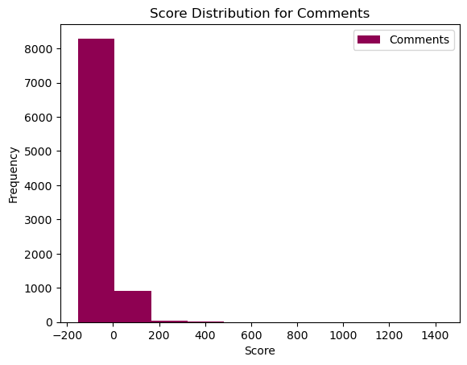

```python
# Collect the 'score' column for comments
comments_scores = comments_df_dating_small.select('score').toPandas()['score']
# Create histograms
plt.hist(comments_scores, bins=10,label='Comments' , color=plt.cm.PiYG(0))
plt.xlabel('Score')
plt.ylabel('Frequency')
plt.title('Score Distribution for Comments')
plt.legend()
plt.savefig('../data/plots/comments_score_distribution.png')
plt.show()
```

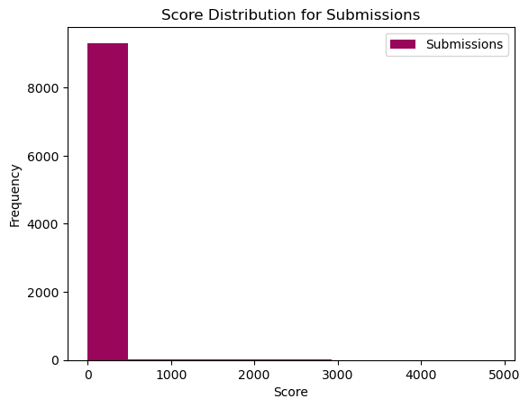

```python
# Collect the 'score' column for submission
comments_scores = submissions_df_dating_small.select('score').toPandas()['score']
# Create histograms
plt.hist(comments_scores, bins=10, label='Submissions' , color=plt.cm.PiYG(5))
plt.xlabel('Score')
plt.ylabel('Frequency')
plt.title('Score Distribution for Submissions')
plt.legend()
plt.savefig('../data/plots/Submissions_score_distribution.png')
plt.show()
```

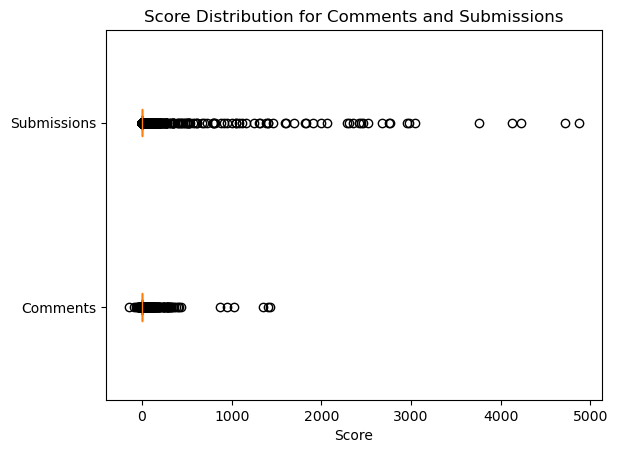

```python
# Collect the 'score' column for comments and submissions
comments_scores = comments_df_dating_small.select('score').toPandas()['score']
submissions_scores = submissions_df_dating_small.select('score').toPandas()['score']

# Create box plots for comments and submissions
plt.boxplot([comments_scores, submissions_scores], vert=False, labels=['Comments', 'Submissions'], patch_artist=True, boxprops=dict(facecolor='pink'))

plt.xlabel('Score')
plt.title('Score Distribution for Comments and Submissions')
plt.savefig('../data/plots/Submissions_Comments_score_distribution.png')
plt.show()
```

> From this box plot, it is evident that the range of scores for submissions is larger than that of comments. Additionally, the mean score for submissions is higher than that of comments.

## Plot 2: Number of comments distribution

```python
from pyspark.sql.functions import col, desc
# Sort the DataFrame by the 'score' column in descending order
sorted_sub_df = submissions_df_dating_small.orderBy(col('num_comments').desc())

# Show only the 'num_comments' column for the top 5 rows
top5_num_comments = sorted_sub_df.limit(5).select('num_comments')
top5_num_comments.show()
```

```
+------------+
|num_comments|
+------------+
|        1080|
|        1053|
|         989|
|         963|
|         923|
+------------+
```

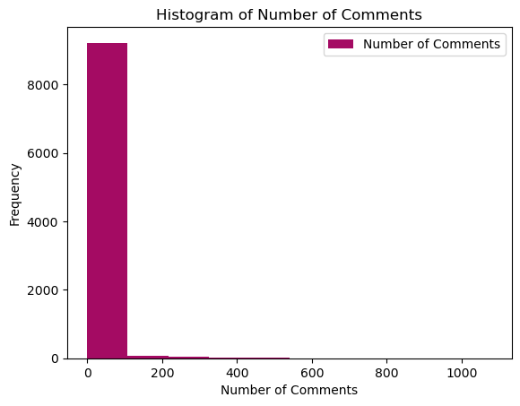

```python
# Collect the 'comment_count' column
comment_counts = submissions_df_dating_small.select('num_comments').toPandas()['num_comments']

# Plot the histogram for the number of comments
plt.hist(comment_counts, bins=10, label='Number of Comments', color=plt.cm.PiYG(10))
plt.xlabel('Number of Comments')
plt.ylabel('Frequency')
plt.title('Histogram of Number of Comments')
plt.legend()
plt.savefig('../data/plots/Histogram_of_Number_of_Comments.png')
plt.show()
```

> According to the table and plot, the distribution of the number of comments of each submission is skewed right. The number of submissions is less than 100. However, we can see some submissions have many comments, which means they are really hot.

## Plot 3: What’s the top 10 hot titles highly discussed in Reddit accoring to score?

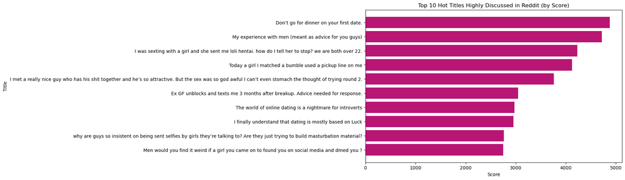

```python
# Sort DataFrame by 'score' in descending order
sorted_submissions = submissions_df_dating_small.sort(submissions_df_dating_small['score'].desc())

# Collect the top 10 records into a Pandas DataFrame
top_10_titles_by_score = sorted_submissions.limit(10).toPandas()

# Create a horizontal bar graph
plt.figure(figsize=(10, 6))
plt.barh(top_10_titles_by_score['title'], top_10_titles_by_score['score'], color=plt.cm.PiYG(20))
plt.xlabel('Score')
plt.ylabel('Title')
plt.title('Top 10 Hot Titles Highly Discussed in Reddit (by Score)')
plt.gca().invert_yaxis()
plt.savefig('../data/plots/Top_10_Hot_Titles_by_Score.png')
plt.show()
```

## Plot 4: What’s the top 10 hot titles highly discussed in reddit accoring to number of comments?

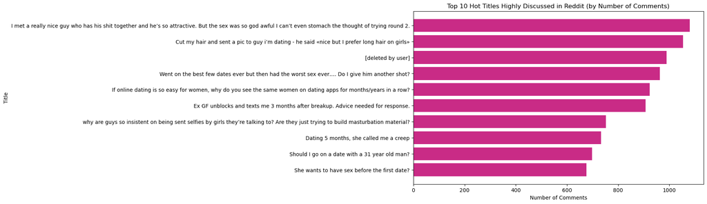

```python
# Sort DataFrame by 'num_comments' in descending order
sorted_submissions = submissions_df_dating_small.sort(submissions_df_dating_small['num_comments'].desc())

# Collect the top 10 records into a Pandas DataFrame
top_10_titles_by_num_comments = sorted_submissions.limit(10).toPandas()

# Create a horizontal bar graph
plt.figure(figsize=(10, 6))
plt.barh(top_10_titles_by_num_comments['title'], top_10_titles_by_num_comments['num_comments'], color=plt.cm.PiYG(30))
plt.xlabel('Number of Comments')
plt.ylabel('Title')
plt.title('Top 10 Hot Titles Highly Discussed in Reddit (by Number of Comments)')
plt.gca().invert_yaxis()
plt.savefig('../data/plots/Top_10_Hot_Titles_by_Comments.png')

plt.show()
```

> Based on the number of comments, the top 10 titles on Reddit are chosen. Most people prefer discussing 'People who are attractive but have terrible sex.' This similar title is even discussed twice in the top 10 titles.

## Plot 5: Scatter Plot of Submission Scores vs. Number of Comments:

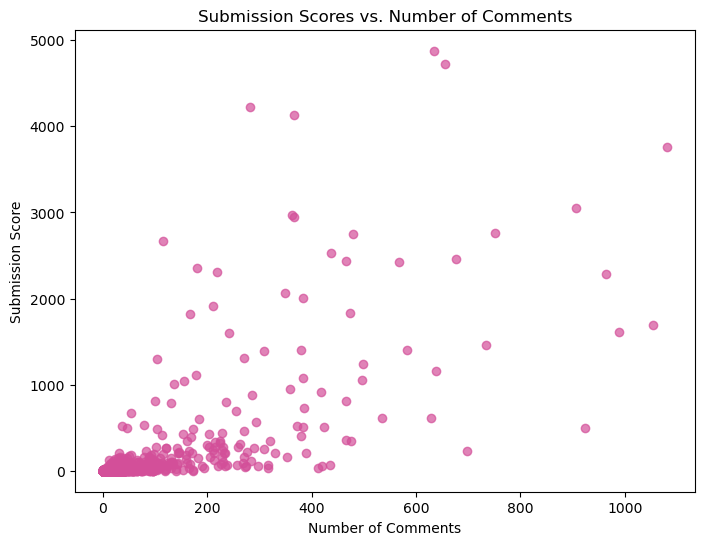

```python
# Collect the data
import matplotlib.pyplot as plt
comment_data = submissions_df_dating_small.select('num_comments', 'score').toPandas()

# Create a scatter plot
plt.figure(figsize=(8, 6))
plt.scatter(comment_data['num_comments'], comment_data['score'], alpha=0.7, color=plt.cm.PiYG(40))
plt.xlabel('Number of Comments')
plt.ylabel('Submission Score')
plt.title('Submission Scores vs. Number of Comments')
plt.savefig('../data/plots/Comment_Scores_vs_Number_of_Comments.png')
plt.show()
```

> From this scatter plot, most of the scores are below 1000, and most of the submissions have fewer than 400 comments. It appears that there is a positive relationship between submission scores and the number of comments in this plot.

## Plot 6: Understand the monthly trends in subreddit activity on Reddit

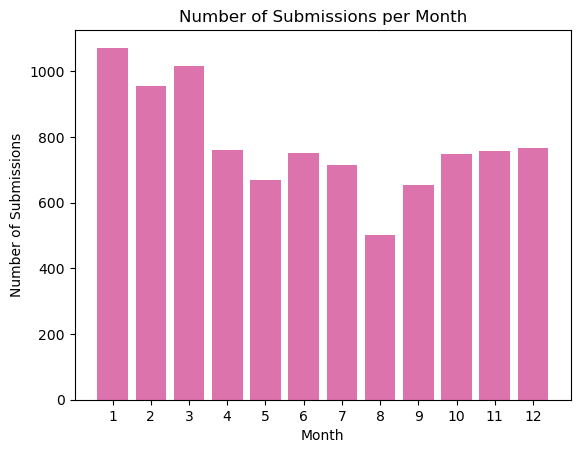

```python
from pyspark.sql.functions import month, size
# Extract the month from the datetime
submissions_df_dating_small = submissions_df_dating_small.withColumn("month", month(submissions_df_dating_small["created_utc"]))

# Group by month and count the occurrences
month_counts = submissions_df_dating_small.groupBy("month").count().orderBy("month")

month_counts_df = month_counts.toPandas()

# Create a bar plot
plt.bar(month_counts_df["month"], month_counts_df["count"], color=plt.cm.PiYG(50))
plt.xlabel("Month")
plt.ylabel("Number of Submissions")
plt.title("Number of Submissions per Month")
plt.xticks(range(1, 13))
plt.savefig('../data/plots/Number_of_Submissions_per_Month.png')
plt.show()
```

> From this bar plot, it is evident that most people seek dating advice in January, while the lowest frequency of people asking for dating advice occurs in August.

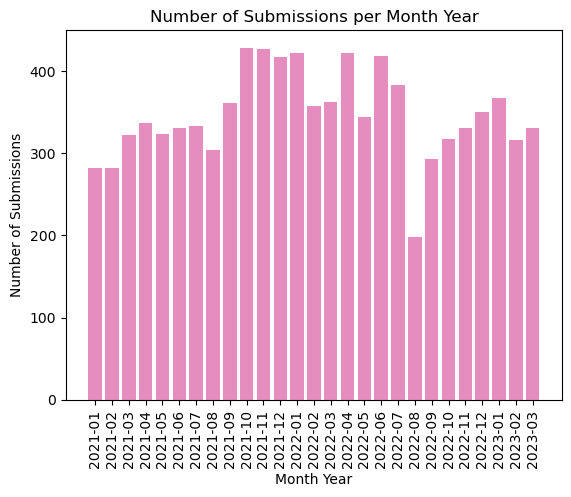

```python
# Extract the month and year from the datetime
from pyspark.sql.functions import date_format
submissions_df_dating_small = submissions_df_dating_small.withColumn("month_year", date_format(submissions_df_dating_small["created_utc"], "yyyy-MM"))

# Group by month_year and count the occurrences
month_year_counts = submissions_df_dating_small.groupBy("month_year").count().orderBy("month_year")

month_year_counts_df = month_year_counts.toPandas()

# Create a bar plot
plt.bar(month_year_counts_df["month_year"], month_year_counts_df["count"], color=plt.cm.PiYG(60))
plt.xlabel("Month Year")
plt.ylabel("Number of Submissions")
plt.title("Number of Submissions per Month Year")
plt.xticks(rotation=90)
plt.savefig('../data/plots/Number_of_Submissions_per_Month_Year.png')
plt.show()
```

> In this sample data, it is evident that people in August 2022 had the lowest frequency of asking for dating advice, while in October 2021, the highest frequency of people seeking dating advice was observed.

## Plot 7: Gilded distribution

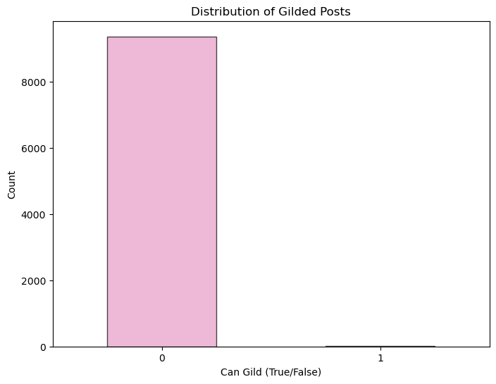

```python
# Collect the 'gilded' column
gilded_data = submissions_df_dating_small.select('gilded').toPandas()['gilded']

# Create a bar plot
plt.figure(figsize=(8, 6))
gilded_data.value_counts().plot(kind='bar', edgecolor='black', alpha=0.7, color=plt.cm.PiYG(65))
plt.xlabel('Can Gild (True/False)')
plt.ylabel('Count')
plt.title('Distribution of Gilded Posts')
plt.xticks(rotation=0)
plt.savefig('../data/plots/Distribution_of_Gilded_submission.png')
plt.show()
```

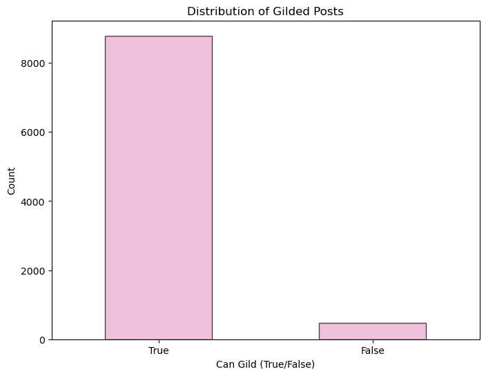

```python
# Collect the 'can_gild' column from the Spark DataFrame into a Pandas Series
gilded_data = comments_df_dating_small.select('can_gild').toPandas()['can_gild']

# Create a bar plot
plt.figure(figsize=(8, 6))
gilded_data.value_counts().plot(kind='bar', edgecolor='black', alpha=0.7, color=plt.cm.PiYG(70))
plt.xlabel('Can Gild (True/False)')
plt.ylabel('Count')
plt.title('Distribution of Gilded Posts')
plt.xticks(rotation=0)  # Keep x-axis labels horizontal
plt.savefig('../data/plots/Distribution_of_Gilded_comments.png')
plt.show()
```

## Plot 8: Over_18 Distribution

[figure not shown]

```python
# Calculate the counts of "over 18" and "not over 18" posts
over_18_counts = submissions_df_dating_small.groupBy("over_18").count().toPandas()

colors = [plt.cm.PiYG(70), plt.cm.PiYG(20)]

# Create a pie plot
plt.figure(figsize=(6, 6))
plt.pie(over_18_counts["count"], labels=["Not Over 18", "Over 18"], autopct='%1.1f%%', startangle=140, colors=colors)
plt.title('Distribution of "Over 18" Posts', color='black')  # Set title color
plt.savefig('../data/plots/Distribution_of_over_18.png')
plt.show()
```

## Plot 9: Length of comments distribution

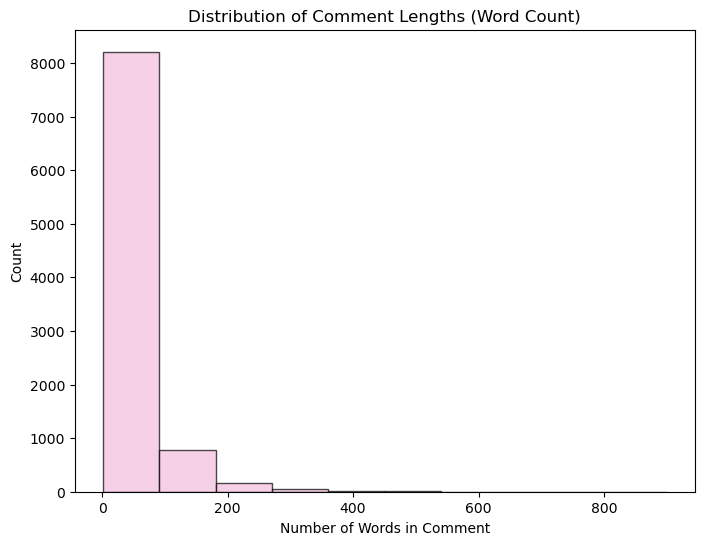

```python
# Split the "body" column by spaces and count the words
import pyspark.sql.functions as F
comments_df_dating_small = comments_df_dating_small.withColumn("comment_length", size(F.split(comments_df_dating_small["body"], " ")))

comment_lengths = comments_df_dating_small.select("comment_length").toPandas()

# Create a histogram of comment lengths based on word count
plt.figure(figsize=(8, 6))
plt.hist(comment_lengths["comment_length"], bins=10, edgecolor='black', alpha=0.7, color=plt.cm.PiYG(80))
plt.xlabel('Number of Words in Comment')
plt.ylabel('Count')
plt.title('Distribution of Comment Lengths (Word Count)', color='black')
plt.savefig('../data/plots/Distribution_Comment_Lengths.png')

plt.show()
```

> In comments, people prefer to use fewer words, typically ranging from 0 to 100. However, there are still some comments with more than 500 words.

# **Produce at least 3 interesting summary tables about your dataset. You can decide how to split up your data into categories, time slices, etc. There are infinite ways you can make summary statistics. Be unique, creative, and interesting!**

## Table 1: Summary statistics for the 'score' and 'num_comments' columns in the 'submissions_df_small' DataFrame.

```python
# Summary statistics of comment scores and num_commets in submission
submissions_df_dating_small.select('score', 'num_comments').describe().show()
```

```
+-------+------------------+------------------+
|summary|             score|      num_comments|
+-------+------------------+------------------+
|  count|              9367|              9367|
|   mean|14.961887477313974|11.538486174869222|
| stddev| 161.5107637891527|46.128162494927665|
|    min|                 0|                 0|
|    max|              4878|              1080|
+-------+------------------+------------------+
```

## Table 2: Comment Controversiality Count and average score of each group

```python
from pyspark.sql.functions import avg
# Group by controversiality and calculate the count and average score for each group
controversiality_summary = comments_df_dating_small.groupBy("controversiality").agg(
    avg("score").alias("average_score"),
    count("*").alias("comment_count")
)
controversiality_summary.show()
```

```
+----------------+-------------------+-------------+
|controversiality|      average_score|comment_count|
+----------------+-------------------+-------------+
|               0|  5.465601420328451|         9012|
|               1|0.44214876033057854|          242|
+----------------+-------------------+-------------+
```

## Table 3: Submission Gilded Count and average score of each group

```python
from pyspark.sql.functions import avg
# Group by Gilded and calculate the count and average score for each group
Gilded_summary = submissions_df_dating_small.groupBy("gilded").agg(
    avg("score").alias("average_score"),
    count("*").alias("comment_count")
)
Gilded_summary.show()
```

```
+------+------------------+-------------+
|gilded|     average_score|comment_count|
+------+------------------+-------------+
|     0|13.538617669052451|         9361|
|     1|            2235.5|            6|
+------+------------------+-------------+
```

## Table 4: Comments Gilded Count and average score of each group

```python
from pyspark.sql.functions import avg
# Group by Gilded and calculate the count and average score for each group
Gilded_summary = comments_df_dating_small.groupBy("can_gild").agg(
    avg("score").alias("average_score"),
    count("*").alias("comment_count")
)
# Show the resulting table
Gilded_summary.show()
```

```
+--------+-----------------+-------------+
|can_gild|    average_score|comment_count|
+--------+-----------------+-------------+
|    true|5.450967007963595|         8790|
|   false|3.122844827586207|          464|
+--------+-----------------+-------------+
```

### Table 5: Summary of Gilded Comments by Controversiality

```python
# Convert boolean "can_gild" to numeric (0 or 1)
comments_df_dating_small = comments_df_dating_small.withColumn("can_gild_numeric", F.when(F.col("can_gild"), 1).otherwise(0))
# Group by controversiality and calculate the total number of gilded comments
gilded_summary = comments_df_dating_small.groupBy("controversiality").agg(F.sum("can_gild_numeric").alias("total_gilded_comments"))
gilded_summary.show()
```

```
+----------------+---------------------+
|controversiality|total_gilded_comments|
+----------------+---------------------+
|               0|                 8569|
|               1|                  221|
+----------------+---------------------+
```

### Table 6: Summary of Comments by Year and Month

```python
# Group by year and month and count the number of comments in each period
comments_by_year_month = comments_df_dating_small.groupBy("year", "month").count()
# Sort the result in descending order by year and month
comments_by_year_month = comments_by_year_month.orderBy(["year", "month"], ascending=[False, False])
comments_by_year_month.show(5)
print("----------")
# Sort the result in descending order by the "count" column
comments_by_year_month = comments_by_year_month.orderBy("count", ascending=False)
comments_by_year_month.show(5)
```

```
+----+-----+-----+
|year|month|count|
+----+-----+-----+
|2023|    3|  339|
|2023|    2|  300|
|2023|    1|  359|
|2022|   12|  349|
|2022|   11|  311|
+----+-----+-----+
only showing top 5 rows

----------
+----+-----+-----+
|year|month|count|
+----+-----+-----+
|2021|   12|  528|
|2021|   10|  490|
|2022|    1|  478|
|2021|   11|  475|
|2021|    9|  418|
+----+-----+-----+
only showing top 5 rows
```

# **Use data transformations to make AT LEAST 3 new variables that are relevant to your business questions. We cannot be more specific because this depends on your project and what you want to explore!**

## New Variable 1: Comment Length

- Calculate the length of each comment. Longer comment may indicate more detailed content.

```python
from pyspark.sql.functions import split, size
# Split the "body" column by spaces, count the words, and add a new column "comment_length"
comments_df_dating_small = comments_df_dating_small.withColumn("comment_length", size(split(comments_df_dating_small["body"], " ")))
comments_df_dating_small.select("body", "comment_length").show(5, truncate=False)
```

```
+-----------------------------------------------------------------------------------------------------------------------------------------------------------------------------------------------------------------------------------------------------------------------------------------------------------…
|body                                                                                                                                                                                                                                                                                                       …
+-----------------------------------------------------------------------------------------------------------------------------------------------------------------------------------------------------------------------------------------------------------------------------------------------------------…
|nope because it's fucking gross. if you want a prostitute just go get one.\n\npeople should NEVER expect sex on dates. you're disgusting.                                                                                                                                                                  …
|Alright, that makes a difference.                                                                                                                                                                                                                                                                          …
|What about work?, you need to shoot your shot 😅 with good candidates of course.                                                                                                                                                                                                                            …
|My man doesn’t feed me, he’s all the way in buttfuck Utah, I’m in buttfuck Louisiana. We’ve been like this the past 4 years. I’ve met him. But we don’t get to see each other and I take care of myself, he takes care of himself. \n\nI don’t hate you either I’m just pissed off today. Reddit is my only…
|Tbh it was mostly women i had seen with their socials linked so I'm not sure if it's as common with men.                                                                                                                                                                                                   …
+-----------------------------------------------------------------------------------------------------------------------------------------------------------------------------------------------------------------------------------------------------------------------------------------------------------…
only showing top 5 rows
```

## New Variable 2: Submission Popularity Score

- Calculate a popularity score for each submission based on the number of comments, score, and gilded count. This score can help to identify the most popular submissions.

```python
# Define a formula for calculating the popularity score
submissions_df_dating_small = submissions_df_dating_small.withColumn("popularity_score", (submissions_df_dating_small["num_comments"] + submissions_df_dating_small["score"] + submissions_df_dating_small["gilded"]).cast("double"))
submissions_df_dating_small.select("num_comments", "score", "gilded", "popularity_score").show(5)
```

```
+------------+-----+------+----------------+
|num_comments|score|gilded|popularity_score|
+------------+-----+------+----------------+
|          14|    1|     0|            15.0|
|          12|    2|     0|            14.0|
|           9|    2|     0|            11.0|
|           5|    3|     0|             8.0|
|           0|    1|     0|             1.0|
+------------+-----+------+----------------+
only showing top 5 rows
```

## New Variable 3: Submission Time of Day Variable

- Categorize submissions into time-of-day segments (e.g., morning, afternoon, evening) based on the created_utc timestamp to understand when most submissions are made.

```python
from pyspark.sql.functions import hour,when
# Categorize submissions into time-of-day segments
submissions_df_dating_small = submissions_df_dating_small.withColumn("submission_time_of_day",
                        when((hour(submissions_df_dating_small["created_utc"]) >= 6) & (hour(submissions_df_dating_small["created_utc"]) < 12), "Morning")
                       .when((hour(submissions_df_dating_small["created_utc"]) >= 12) & (hour(submissions_df_dating_small["created_utc"]) < 18), "Afternoon")
                       .when((hour(submissions_df_dating_small["created_utc"]) >= 18) & (hour(submissions_df_dating_small["created_utc"]) < 24), "Evening")
                       .otherwise("Night"))
submissions_df_dating_small.select("created_utc","submission_time_of_day").show(5)
```

```
+-------------------+----------------------+
|        created_utc|submission_time_of_day|
+-------------------+----------------------+
|2021-08-14 09:43:52|               Morning|
|2021-07-28 21:35:36|               Evening|
|2022-12-11 10:09:57|               Morning|
|2022-12-11 10:43:16|               Morning|
|2022-02-05 12:15:06|             Afternoon|
+-------------------+----------------------+
only showing top 5 rows
```

## New Variable 4: Levels of scores

- Categorize scores into four groups: Negative, Low, Medium, and High.

```python
# Define score categories and their corresponding score ranges
score_categories = {
    "Negative": (float("-inf"), -1),
    "Low": (0, 10),
    "Medium": (11, 100),
    "High": (101, float("inf"))
}

# Create a new column based on score categories
score_column = col("score")
submissions_df_dating_small = submissions_df_dating_small.withColumn(
    "score_category",
    when((score_column >= score_categories["Negative"][0]) & (score_column <= score_categories["Negative"][1]), "Negative")
    .when((score_column >= score_categories["Low"][0]) & (score_column <= score_categories["Low"][1]), "Low")
    .when((score_column >= score_categories["Medium"][0]) & (score_column <= score_categories["Medium"][1]), "Medium")
    .when((score_column >= score_categories["High"][0]) & (score_column <= score_categories["High"][1]), "High")
    .otherwise(None)
)
submissions_df_dating_small.select("score", "score_category").show(5)
```

```
+-----+--------------+
|score|score_category|
+-----+--------------+
|    1|           Low|
|    2|           Low|
|    2|           Low|
|    3|           Low|
|    1|           Low|
+-----+--------------+
only showing top 5 rows
```

# **Implement regex searches for specific keywords of interest to produce dummy variables and then make statistics that are related to your business questions. Note, that you DO NOT have to do textual cleaning of the data at this point. The next assignment on NLP will focus on the textual cleaning and analysis aspect.**

## Keyword 1: Search for Comments Containing "Dating App"

- Choosing ""dating app", "Tinder", "Bumble", "OkCupid"" as the keywords, we searched for comments that contain these words. This analysis allows us to determine whether dating apps play a significant role in the dating context.

```python
from pyspark.sql.functions import when, col

# Define the keywords we want to search for
keywords = ["dating app", "Tinder", "Bumble", "OkCupid","Hinge","Coffee Meets Bagel"]

# Create individual columns for each keyword
for keyword in keywords:
    comments_df_dating_small = comments_df_dating_small.withColumn(f"contains_{keyword}", when(col("body").like(f"%{keyword}%"), True).otherwise(False))

# Create the 'contains_dating_app_keywords' column based on the individual keyword columns
comments_df_dating_small = comments_df_dating_small.withColumn("contains_dating_app_keywords",
                                                              when((col("contains_dating app") | col("contains_Tinder") | col("contains_Bumble") | col("contains_OkCupid")), True).otherwise(False))

# Drop the individual keyword columns
for keyword in keywords:
    comments_df_dating_small = comments_df_dating_small.drop(f"contains_{keyword}")

comments_df_dating_small.show(5)
```

```
+-------+------------------+--------------------+-------------------+-----+-------------+------------+----------------+------+--------+--------------------+--------+----+-----+--------------+----------------------------+
|     id|            author|                body|        created_utc|score|    subreddit|subreddit_id|controversiality|gilded|can_gild|           permalink|stickied|year|month|comment_length|contains_dating_app_keywords|
+-------+------------------+--------------------+-------------------+-----+-------------+------------+----------------+------+--------+--------------------+--------+----+-----+--------------+----------------------------+
|hfbuuzs|throwaway291111988|nope because it's...|2021-10-04 08:22:50|   17|dating_advice|    t5_2s4kl|               0|     0|    true|/r/dating_advice/...|   false|2021|   10|            22|                       false|
|hjs0sgm|  cinder_likes_tea|Alright, that mak...|2021-11-08 07:05:44|    1|dating_advice|    t5_2s4kl|               0|     0|    true|/r/dating_advice/...|   false|2021|   11|             5|                       false|
|hh1m907|      Dry_Gas_9765|What about work?,...|2021-10-17 23:17:43|    1|dating_advice|    t5_2s4kl|               0|     0|    true|/r/dating_advice/...|   false|2021|   10|            15|                       false|
|hf5ezyw|      SilvaFish420|My man doesn’t fe...|2021-10-02 22:08:05|    2|dating_advice|    t5_2s4kl|               0|     0|    true|/r/dating_advice/...|   false|2021|   10|            70|                       false|
|haes9d7|         [deleted]|Tbh it was mostly...|2021-08-26 11:12:15|    1|dating_advice|    t5_2s4kl|               0|     0|   false|/r/dating_advice/...|   false|2021|    8|            22|                       false|
+-------+------------------+--------------------+-------------------+-----+-------------+------------+----------------+------+--------+--------------------+--------+----+-----+--------------+----------------------------+
only showing top 5 rows
```

```python
from pyspark.sql.functions import sum
# Total number of comments
total_comments = comments_df_dating_small.count()

# Count the number of comments containing the keyword
count_dating_apps_comments_true = comments_df_dating_small.filter(col("contains_dating_app_keywords") == True).count()
count_dating_apps_comments_false = comments_df_dating_small.filter(col("contains_dating_app_keywords") == False).count()

print(f"Number of comments containing dating app keywords: {count_dating_apps_comments_true}")
print(f"Number of comments not containing dating app keywords: {count_dating_apps_comments_false}")

# Percantage
percentage_dating_apps_comments = (count_dating_apps_comments_true / total_comments) * 100
print(f"Percentage of comments containing dating app keywords: {percentage_dating_apps_comments:.2f}%")
```

```
Number of comments containing dating app keywords: 134
Number of comments not containing dating app keywords: 9120
Percentage of comments containing dating app keywords: 1.45%
```

# **Find some type of external data to join onto your Reddit data. Don’t know what to pick? Consider a time-related dataset. Stock prices, game details over time, active users on a platform, sports scores, covid cases, etc., etc. While you may not need to join this external data with your entire dataset, you must have at least one analysis that connects to external data. You do not have to join the external data and analyze it yet, just find it.**

## External data: https://www.kaggle.com/datasets/sidharthkriplani/datingappreviews/

> The external dataset, sourced from Kaggle, comprises a rich collection of dating app reviews and associated ratings. This dataset serves as a valuable resource for our project, aligning perfectly with our core business objective: to investigate the pivotal role of dating apps in the dating and relationship landscape of contemporary society. By delving into the comprehensive set of app reviews and their corresponding ratings, our aim is to uncover profound insights that shed light on the influence, significance, and overall impact of dating apps in the context of modern dating and relationships. This data will empower us to make informed assessments and draw conclusions regarding the evolving dynamics of romantic connections in today's digital age.

## Read dataset

```python
import pandas as pd
df_kaggle = pd.read_csv("../data/csv/DatingAppReviewsDataset.csv")
df_kaggle.head()
```

|  | Unnamed: 0 | Name | Review | Rating | #ThumbsUp | Date&Time | App |
| --- | --- | --- | --- | --- | --- | --- | --- |
| 0 | 0 | linah sibanda | On this app i cant find a partner | 5 | 0 | 18-02-2022 01:19 | Tinder |
| 1 | 1 | Norman Johnson | Tinder would be so much better if we could spe... | 3 | 0 | 18-02-2022 01:16 | Tinder |
| 2 | 2 | David Hume | Still doesn't correctly notify matches or mess... | 1 | 0 | 18-02-2022 01:11 | Tinder |
| 3 | 3 | Last 1 Standing | Got banned because I updated my bio to say "I ... | 2 | 0 | 18-02-2022 01:11 | Tinder |
| 4 | 4 | Arthur Magamedov | Love it! | 5 | 0 | 18-02-2022 01:06 | Tinder |

```python
df_kaggle.shape
```

```
(681994, 7)
```

```python
df_kaggle.info()
```

```
<class 'pandas.core.frame.DataFrame'>
RangeIndex: 681994 entries, 0 to 681993
Data columns (total 7 columns):
 #   Column      Non-Null Count   Dtype
---  ------      --------------   -----
 0   Unnamed: 0  681994 non-null  int64
 1   Name        681989 non-null  object
 2   Review      680642 non-null  object
 3   Rating      681994 non-null  int64
 4   #ThumbsUp   681994 non-null  int64
 5   Date&Time   681994 non-null  object
 6   App         681994 non-null  object
dtypes: int64(3), object(4)
memory usage: 36.4+ MB
```

```python
df_kaggle.describe()
```

|  | Unnamed: 0 | Rating | #ThumbsUp |
| --- | --- | --- | --- |
| count | 681994.000000 | 681994.000000 | 681994.000000 |
| mean | 213062.414738 | 2.997183 | 1.873719 |
| std | 163040.355531 | 1.746953 | 24.448095 |
| min | 0.000000 | 0.000000 | 0.000000 |
| 25% | 58752.000000 | 1.000000 | 0.000000 |
| 50% | 185618.500000 | 3.000000 | 0.000000 |
| 75% | 356116.750000 | 5.000000 | 0.000000 |
| max | 526615.000000 | 5.000000 | 5507.000000 |

### Data Cleaning

```python
df_kaggle.isna().sum()
```

```
Unnamed: 0       0
Name             5
Review        1352
Rating           0
#ThumbsUp        0
Date&Time        0
App              0
dtype: int64
```

```python
df_kaggle.rename(columns={'Unnamed: 0':'id'},inplace=True)
df_kaggle["Date"] = pd.to_datetime(df_kaggle['Date&Time']).dt.date
df_kaggle["Time"] = pd.to_datetime(df_kaggle['Date&Time']).dt.time
```

```python
df_kaggle.head()
```

|  | id | Name | Review | Rating | #ThumbsUp | Date&Time | App | Date | Time |
| --- | --- | --- | --- | --- | --- | --- | --- | --- | --- |
| 0 | 0 | linah sibanda | On this app i cant find a partner | 5 | 0 | 18-02-2022 01:19 | Tinder | 2022-02-18 | 01:19:00 |
| 1 | 1 | Norman Johnson | Tinder would be so much better if we could spe... | 3 | 0 | 18-02-2022 01:16 | Tinder | 2022-02-18 | 01:16:00 |
| 2 | 2 | David Hume | Still doesn't correctly notify matches or mess... | 1 | 0 | 18-02-2022 01:11 | Tinder | 2022-02-18 | 01:11:00 |
| 3 | 3 | Last 1 Standing | Got banned because I updated my bio to say "I ... | 2 | 0 | 18-02-2022 01:11 | Tinder | 2022-02-18 | 01:11:00 |
| 4 | 4 | Arthur Magamedov | Love it! | 5 | 0 | 18-02-2022 01:06 | Tinder | 2022-02-18 | 01:06:00 |

## EDA

### 1. Number of each app was reviewed

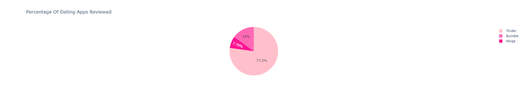

```python
import plotly.express as px
# Calculate the value counts for the 'App' column
app_counts = df_kaggle['App'].value_counts()
# Calculate the percentages
percentages = (app_counts / app_counts.sum()) * 100
# Define a list of different shades of pink
pink_colors = ['#FFC0CB', '#FF69B4', '#FF1493']

# Create the pie chart with different shades of pink
fig = px.pie(
    names=app_counts.index,
    values=percentages,
    title='Percentage Of Dating Apps Reviewed',
    color_discrete_sequence=pink_colors
)

# Show the plot
fig.show()
fig.write_html('../data/plots/external_data_pie_chart.html')
```

### 2. Calculate the average rating for each app

```python
# Calculate the average rating
average_ratings_by_app = df_kaggle.groupby('App')['Rating'].mean()
# Create a DataFrame from the series
average_ratings_df = pd.DataFrame({'App': average_ratings_by_app.index, 'Average_Rating': average_ratings_by_app.values})
# Print the resulting DataFrame
print(average_ratings_df)
```

```
      App  Average_Rating
0  Bumble        2.832269
1   Hinge        3.180888
2  Tinder        3.010759
```

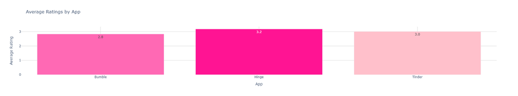

```python
import plotly.express as px

# Assuming you have the DataFrame named 'average_ratings_df' with the 'App' and 'Average_Rating' columns
fig = px.bar(average_ratings_df, x='App', y='Average_Rating', title='Average Ratings by App', text_auto='.2s')
pink_colors = ['#FF69B4','#FF1493','#FFC0CB']
fig.update_traces(marker_color=pink_colors)
fig.update_layout(
    plot_bgcolor='white',  # Set the background color to light gray
    paper_bgcolor='white',
    xaxis=dict(showgrid=True, gridcolor='lightgray'),
    yaxis=dict(showgrid=True, gridcolor='lightgray')
)
fig.update_yaxes(title_text='Average Rating')

# Show the plot
fig.show()
fig.write_html('../data/plots/external_data_app_average_rating.html')
```

> Hinge has the highest average rating in three of all.

### 3. Calculate number of review on each day

```python
data_groupby = df_kaggle.groupby(['Date'])['Date'].count()
# Sort the result in descending order
sorted_data_groupby = data_groupby.sort_values(ascending=False)
print(sorted_data_groupby[:5])
# Create a DataFrame from the series
data_groupby = pd.DataFrame({'Date': data_groupby.index, 'Count': data_groupby.values})
```

```
Date
2016-11-15    1672
2017-03-26    1227
2019-09-17     807
2019-04-23     799
2015-03-03     757
Name: Date, dtype: int64
```

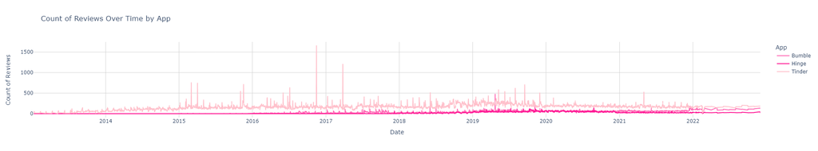

```python
grouped_data = df_kaggle.groupby(['Date', 'App'])['Review'].count().reset_index()
pivot_table = grouped_data.pivot(index='Date', columns='App', values='Review').fillna(0)
pivot_table.reset_index(inplace=True)
pink_colors = ['#FF69B4','#FF1493','#FFC0CB']

import plotly.express as px

fig = px.line(pivot_table, x='Date', y=pivot_table.columns[1:], title='Count of Reviews Over Time by App')
for i, color in enumerate(pink_colors):
    fig.update_traces(selector=dict(name=pivot_table.columns[i + 1]), line_color=color, line_width=2)
fig.update_layout(
    plot_bgcolor='white',
    paper_bgcolor='white',
    xaxis_title='Date',
    yaxis_title='Count of Reviews',
    legend_title='App',
    xaxis=dict(showgrid=True, gridcolor='lightgray'),
    yaxis=dict(showgrid=True, gridcolor='lightgray')
)

# Plot show
fig.show()
fig.write_html('../data/plots/external_data_app_count_reviews.html')
```

> The time for comments on Tinder fluctuates greatly. The other two are relatively stable.

### 4. Word Cloud

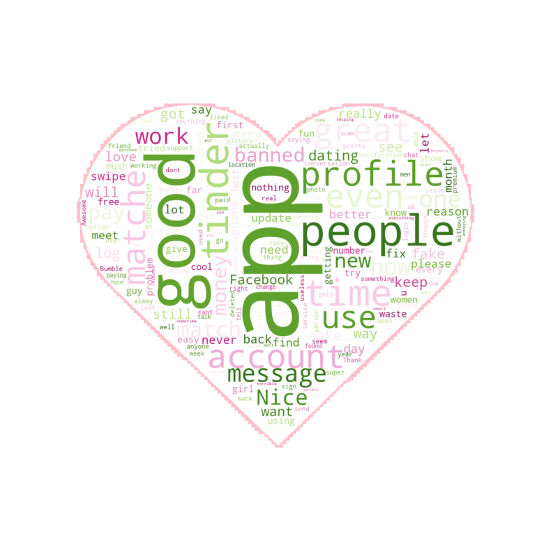

```python
from wordcloud import WordCloud, STOPWORDS
import matplotlib.pyplot as plt
from PIL import Image
import numpy as np

# Load the image of a heart shape
heart_mask = np.array(Image.open('../data/plots/heart2.png'))
# Generate a word cloud image
wordcloud = WordCloud(
    background_color='white',
    mask=heart_mask,
    colormap='PiYG',
    contour_width=3,
    contour_color='pink',
    width=800,
    height=500,
    collocations=False
).generate(' '.join(df_kaggle['Review'].dropna()))
# Display
plt.figure(figsize=(10, 10))
plt.imshow(wordcloud, interpolation='bilinear')
plt.axis('off')
plt.show()
fig.write_html('../data/plots/external_data_wordcloud.html')
```

> The most commonly used words in reviews are "good" and "app". It seems that most people have a good opinion of dating apps.

### 5. Bi-grams

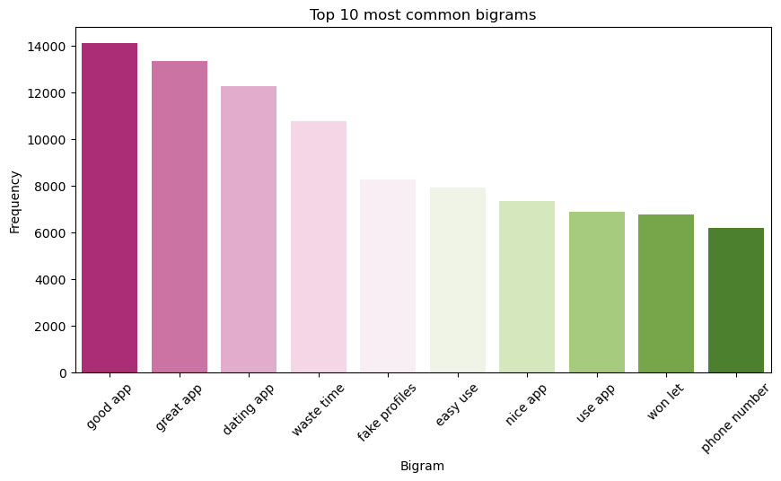

```python
from sklearn.feature_extraction.text import CountVectorizer, TfidfVectorizer
import nltk
from nltk.util import ngrams
from collections import Counter
import seaborn as sns
import matplotlib.pyplot as plt

nltk.download('punkt')

# Bigrams
bigram_vectorizer = CountVectorizer(ngram_range=(2, 2), stop_words='english').fit(df_kaggle['Review'].dropna())
bigram_bag_of_words = bigram_vectorizer.transform(df_kaggle['Review'].dropna())
sum_bigrams = bigram_bag_of_words.sum(axis=0)
bigrams_freq = [(bigram, sum_bigrams[0, idx]) for bigram, idx in bigram_vectorizer.vocabulary_.items()]
bigrams_freq = sorted(bigrams_freq, key=lambda x: x[1], reverse=True)
bigrams_df = pd.DataFrame(bigrams_freq[:10], columns=['Bigram', 'Frequency'])

# Plot most common bigrams
plt.figure(figsize=(10, 5))
sns.barplot(x='Bigram', y='Frequency', data=bigrams_df, palette='PiYG')
plt.title('Top 10 most common bigrams')
plt.xticks(rotation=45)
plt.show()
fig.write_html('../data/plots/external_data_top10_bigrams.html')
```

> Most people maintain a good opinion of dating apps.

### 6. Sentiment Analysis

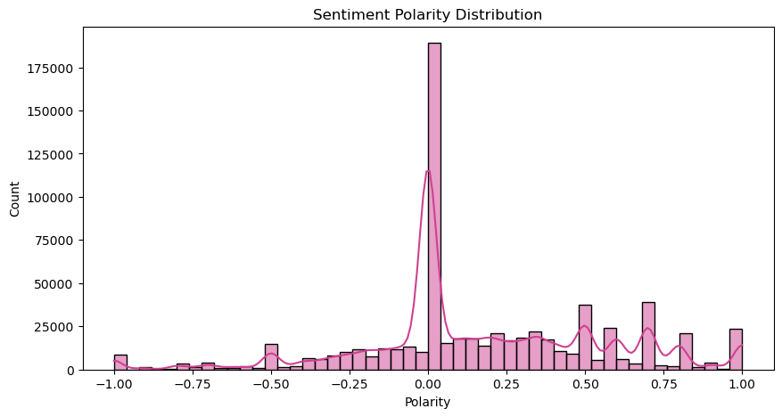

```python
from textblob import TextBlob

df_kaggle = df_kaggle.dropna(subset=['Review'])
df_kaggle['Polarity'] = df_kaggle['Review'].map(lambda text: TextBlob(text).sentiment.polarity)
sns.set_palette("PiYG")
plt.figure(figsize=(10, 5))
sns.histplot(df_kaggle['Polarity'], bins=50, kde=True)
plt.title('Sentiment Polarity Distribution')
plt.show()
fig.write_html('../data/plots/external_data_sentiment_polarity.html')
```

> Most people maintain a neutral and favorable view of dating apps.